# Data Visualization With ggplot2

Andrew Bates

11/29/2018

### Welcome

In this workshop we will be visualizing data using the R package `ggplot2`. From the [package website](https://ggplot2.tidyverse.org):

> ggplot2 is a system for declaratively creating graphics, based on The Grammar of Graphics. You provide the data, tell ggplot2 how to map variables to aesthetics, what graphical primitives to use, and it takes care of the details.

We will talk more about what this means so don’t worry if this doesn’t make sense yet. If you’ve been to the previous workshops I did, this one will be quite a bit different. It will be more interactive and we will be updating this document as we go. I will demonstrate how to make a couple of simple plots, then I will get your input and we will make some plots together.

### What Makes a Plot?

Before we start actually building plots, let’s take a few minutes to think about what goes into a plot. Consider the following plot.

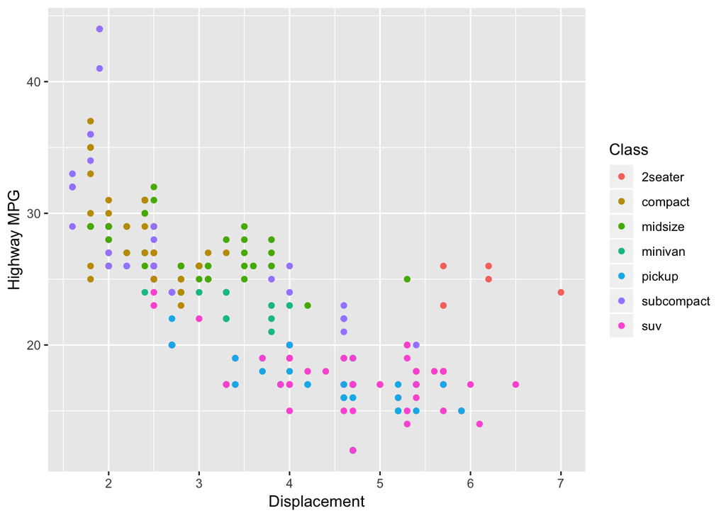

What are the components that go into this plot? If we had to build this up piece by piece, what would the pieces be?

- axes
- axes labels
- legend
- data
- color

This plot was made with one of the data sets that comes with `ggplot2`. The data set has information on fuel economy for cars from 1999-2008. The code to generate the plot is:

```r
ggplot(mpg, aes(x = displ, y = hwy, color = class)) +
  geom_point() +
  labs(x = "Displacement",
       y = "Highway MPG",
       color = "Class")
```

Of the components we listed earlier, which ones do we see reflected in the code?

- color
- labels

Are there any aspects that don’t appear in the code?

- legend

### A First Plot

Now that we have an idea of what some of the pieces of a plot are, let’s make some of our own. We will be using data on NCAA men’s basketball teams from the 2017-2018 season. The data was collected from [sports-reference.com](https://www.sports-reference.com/cbb/seasons/2018-advanced-school-stats.html). Let’s start by loading some packages and reading in the data. Don’t worry about the `here` package if you haven’t seen it before. `ggplot2` is part of the tidyverse so we can load it by loading the `tidyverse` package. There are a few other tidyverse pacakges we will use which is why we laod `tidyverse` instead of just `ggplot2`. You don’t need to worry about the other packages though. Just focus on the `ggplot2` parts.

```r
library(here)
library(tidyverse)
bball <- read_csv(here("fall_18", "data", "ncaa-basketball-17-18.csv"))
```

Let’s make a bar chart that displays the number of wins for each team. We will plot the number of wins on the y axis and the school name on the x axis. There are 351 teams in the data set. Putting them all on the same plot will be a bit overwhelming so let’s just look at the CSU and UC schools. We start by creating a new data frame with only these schools. Again, you don’t need to worry about how this is done, just know that’s what we are doing.

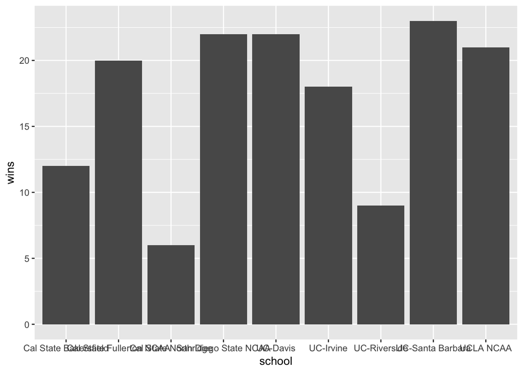

```r
csuc <- bball %>%
  filter(str_detect(school, "Cal State") |
           str_detect(school, "San Diego State") |
           str_detect(school, "UC"))


ggplot(csuc, aes(x = school, y = wins)) +
  geom_col()
```

This isn’t so great. Let’s rotate the names so we can read them and make the bars red and black for SDSU.

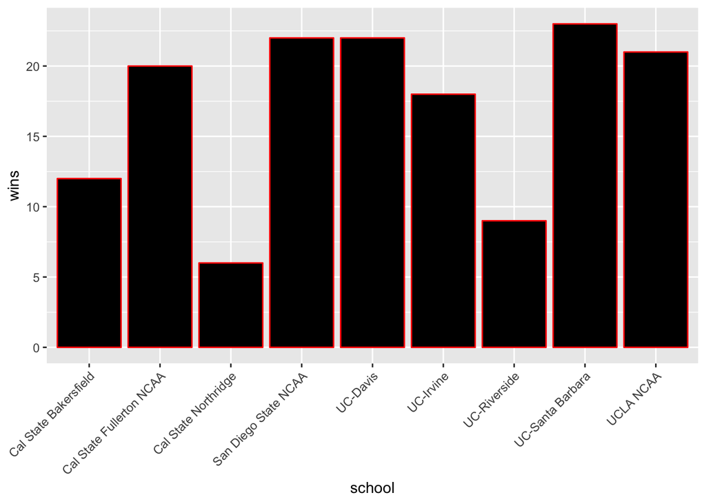

```r
ggplot(csuc, aes(x = school, y = wins)) +
  geom_col(fill = "black", color = "red") +
  theme(axis.text.x = element_text(angle = 45, hjust = 1))
```

### What Do You Want To Plot?

As I said before, I want this workshop to be interactive so I would like your input on what we should plot and then we can do it together. Would you like to plot a particular variable of the NCAA data? Would you like to see how to make a particular type of plot? It doesn’t need to be the NCAA basketball data. As long as we can all access the data easily, we can use any data set you like.

During the workshop we decided that we wanted to see how to make some of the standard plots. We started with a histogram, density, and boxplot of win/loss ratio.

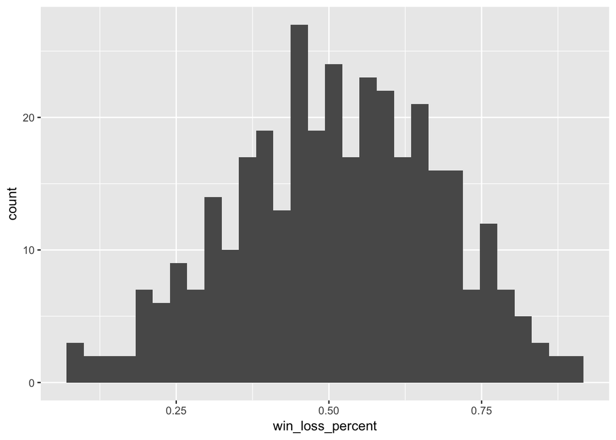

```r
ggplot(bball, aes(x = win_loss_percent)) +
  geom_histogram(bins = 30)
```

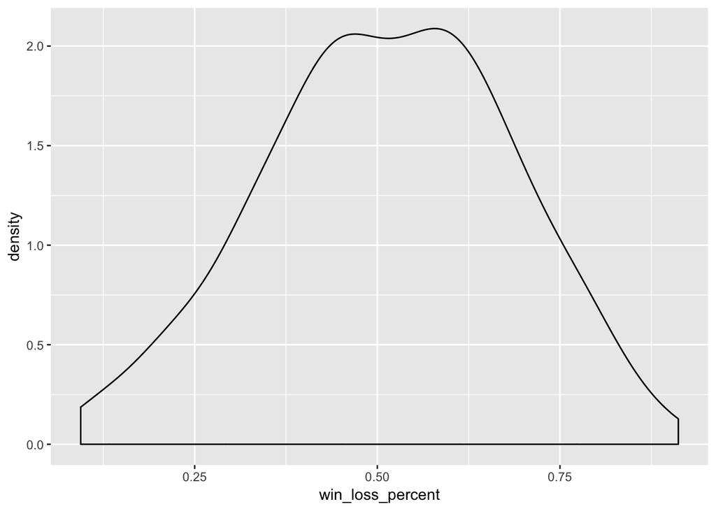

```r
ggplot(bball, aes(x = win_loss_percent)) +
  geom_density()
```

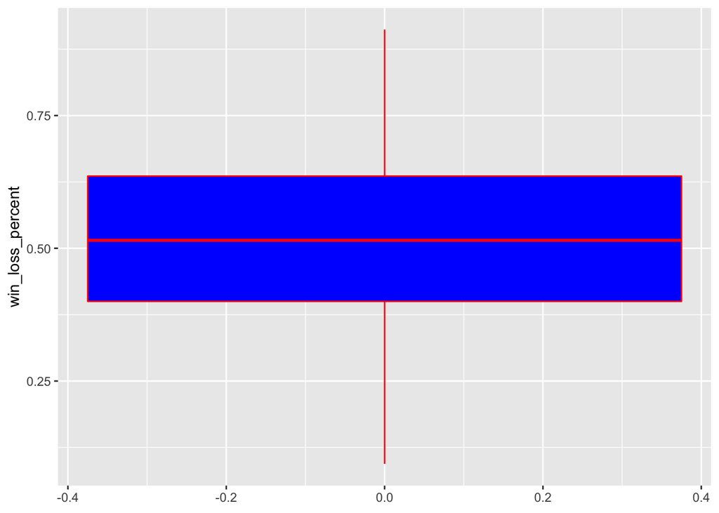

```r
ggplot(bball, aes(y = win_loss_percent)) +
  geom_boxplot(fill = "blue", color = "red")
```

Next we took the first scatter plot from above and added a smoothing line with a linear model. The first one has a separate line for each class of car since `class` was one of the aesthetics specified in the `ggplot()` call. Then we saw how to override this aesthetic and have a single smoothing line for the entire data set.

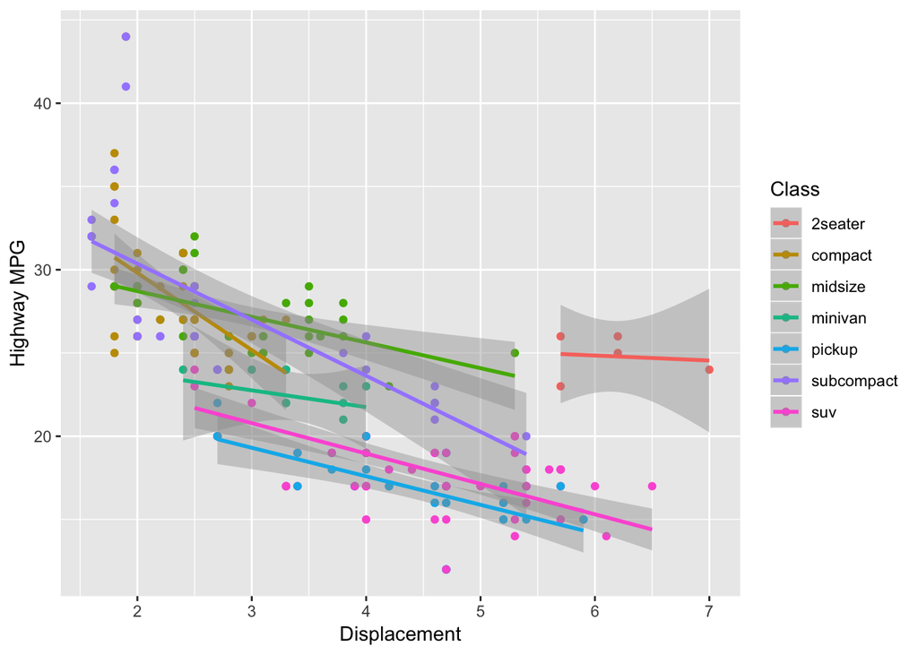

```r
ggplot(mpg, aes(x = displ, y = hwy, color = class)) +
  geom_point() +
  geom_smooth(method = "lm") +
  labs(x = "Displacement",
       y = "Highway MPG",
       color = "Class")
```

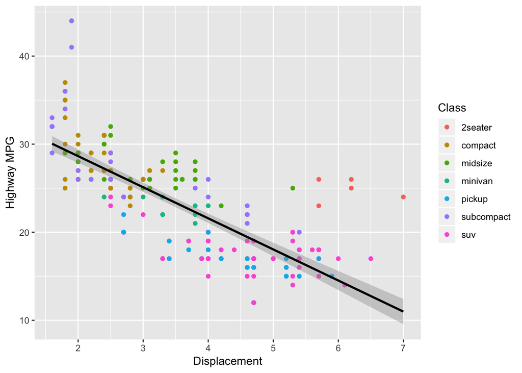

```r
ggplot(mpg, aes(x = displ, y = hwy, color = class)) +
  geom_point() +
  geom_smooth(method = "lm", color = "black") +
  labs(x = "Displacement",
       y = "Highway MPG",
       color = "Class")
```

An example of how to transform an axis scale.

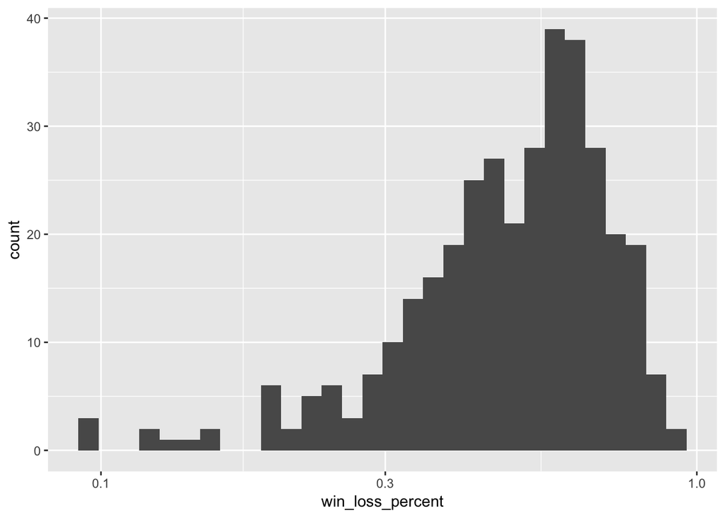

```r
ggplot(bball, aes(x = win_loss_percent)) +
  geom_histogram(bins = 30) +
  scale_x_log10()
```

A qqplot and qqline example.

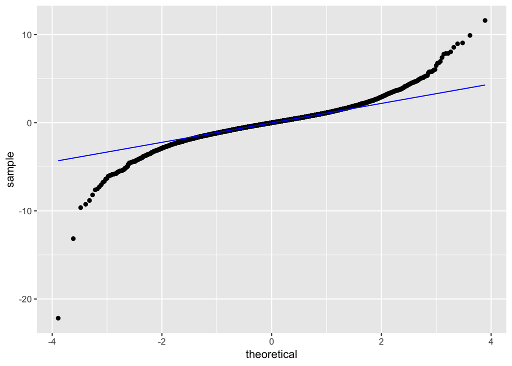

```r
random_t <- data.frame(rt = rt(1e4, df = 4))

ggplot(random_t, aes(sample = rt)) +
  geom_qq() +
  geom_qq_line(color = "blue")
```

An cdf plot. Note the use of `stat_ecdf` instead of `geom_*`.

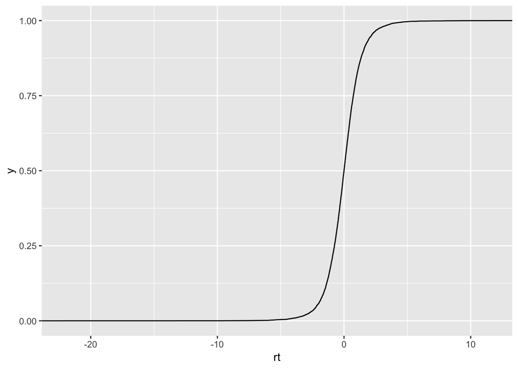

```r
ggplot(random_t, aes(x = rt)) +
  stat_ecdf()
```

Finally, we saw how to change the theme of a plot.

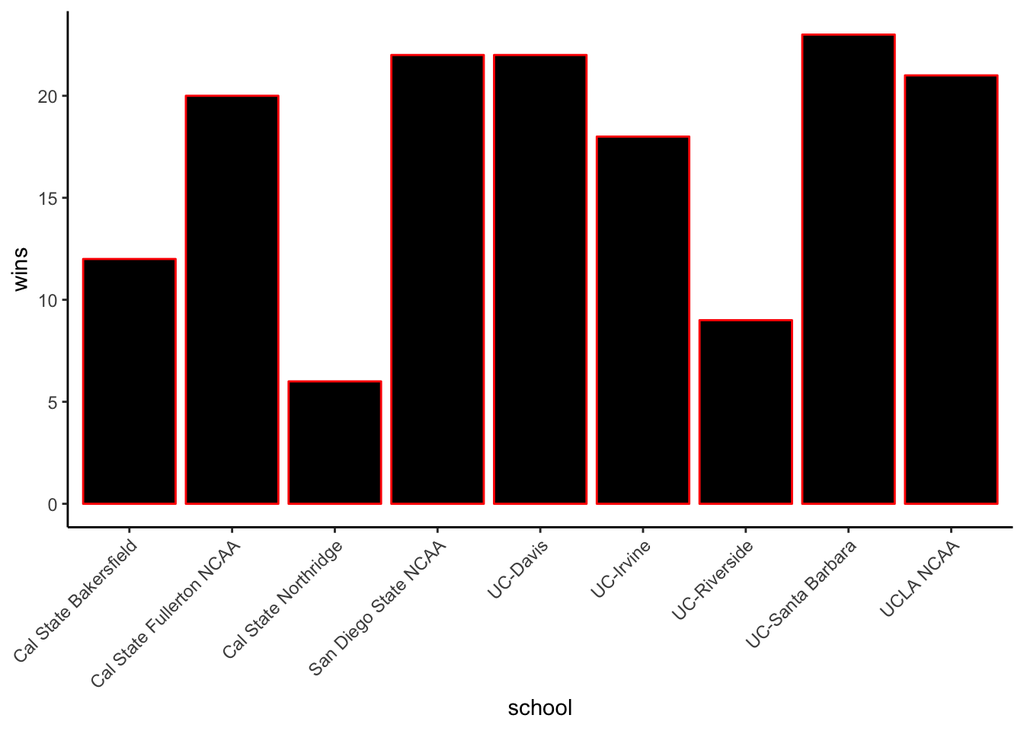

```r
ggplot(csuc, aes(x = school, y = wins)) +
  geom_col(fill = "black", color = "red") +
  # theme_bw() another example of a built in theme
  theme_classic() +
  theme(axis.text.x = element_text(angle = 45, hjust = 1))
```

### References

- [ggplot2 website](https://ggplot2.tidyverse.org)
- [R for Data Science](https://r4ds.had.co.nz): book by `ggplot2` package author
- [Data Camp](https://www.datacamp.com): 3 `ggplot2` courses